# **Projekt "Kaufen oder Warten"?**

Die Situation kennen alle von Ihnen, die mindestens ab und zu Flugtickets kaufen: Ist es besser zu warten, weil der Preis vielleicht noch fällt oder sollen wir kaufen? Insbesondere die Fluggesellschaft, um der es in den Daten geht, ist für scheinbar erratische Preisveränderungen bekannt. Das übliche Vorgehen "je früher desto besser" ist hier oft nicht die beste Empfehlung.

## **Datenbeschreibung**

- Jede Zeile beschreibt eine Preisanfrage zu einem Zeitpunkt für einen Flug
- **zwei** verschiedene **Strecken** in beiden Richtungen:
  - London Stansted ✈ Berlin Schönefeld
  - London Stansted ✈ Frankfurt

**Merkmale**:

- Request_Date: Datum/Zeit der Preisanfrage
- Flight_Date: Datum des Flugs
- Departure_hour: Gerundete Abflugszeit
- flight_unique_id: eindeutige ID für den Flug
- route_abb: Abkürzung der Route
- Price_In_Eur: Flugpreis
- min_future_price_in_Eur: minimaler Flugpreis für die flight_unique_id über alle zukünftigen Request_Dates
- buy: 1 = kaufen, 0 = warten als vorherzusagende Klasse. Berechnet als:

  ```
  if train_set$Price_In_Eur - train_set$min_future_price_in_Eur  <= 0 then 1 else 0
  ```

## **Aufgabe**

Kaufempfehlung durch ML

1. Für den **ersten Teil der Arbeit (Abgabe: 15.12; Präsi: 16.12)** überlegen Sie sich, wie Sie solch ein Modell in der Praxis gestalten und anwenden würden. Versetzen Sie sich dazu in die Lage eines Kunden und/oder in die Lage eines Unternehmens.

   > Was könnte bei letzterem das Geschäftsmodell sein? Welchen Einfluss haben diese Überlegungen auf das Konzept des zu lernenden Modells?
   - **Anforderungen**:
     1. Worum geht es in Ihrem Problem? Wie würden Sie ein Modell einsetzen? Wie würden Sie grundsätzlich die Güte eines Modells messen?
        - Benutzen Sie zunächst einfache Vorhersagegenauigkeit zur Beurteilung der Modellgüte (Accuracy). Messen Sie also die Anzahl der richtigen Entscheidungen (Kaufen oder Warten) durch die Anzahl aller Entscheidungen. Überlegen Sie dann, wie man aus Sicht eines Kunden bzw. Ihres Geschäftsmodells die Güte der Kaufempfehlungen messen sollte. Hier spielen sicher monetäre Überlegungen und Kundenzufriedenheit eine größere Rolle als nur möglichst genaue Empfehlungen. Denken Sie hierbei auch daran, dass man sich als Kunde nicht dem Stress aussetzen möchte, ständig Preise abzufragen.
     2. Deskriptive Analyse der Daten: Was beschreiben die Daten, was sind die Datentypen und Wertebereiche, fehlen Daten, gibt es falsche Werte, gibt es Korrelationen zwischen Merkmalen (Features, Spalten)? Benutzen Sie Visualisierungen, wenn es sinnvoll erscheint. Was können wir aus dieser deskriptiven Analyse über das Problem lernen?
     3. Definieren Sie geeignete Merkmale (Features) für die Klassifikation/Regression/Clustering.
1. Modell bauen
   - **Anforderungen**:
     1. Jede*r in der Gruppe soll ein Verfahren für **Klassifikation/Regression/Clustering anwenden** (insgesamt mindestens zwei pro Gruppe).
     2. Im Fall von Regression/Klassifikation: Benutzen Sie Kreuzvalidierung, um die Hyperparameter zu optimieren und die Qualität der Modelle zu evaluieren (wählen Sie sinnvolle Maße für die Qualität)
     3. Im Fall von Clustering: Optimieren Sie die Hyperparameter und evaluieren Sie die Qualität der Clusteringmodelle
     4. Vergleichen Sie die Ergebnisse der verschiedenen Verfahren

> Weitere Hilfestellung: https://github.com/ageron/handson-ml/blob/master/ml-project-checklist.md

# **Erster Teil**

## Aufgabe 1

Praxis Anwendung für den Kunden:

1. Entscheidung über die nächste Reise (Urlaub, Arbeit)
2. Entscheidung über den Zeitraum des Kaufes

Praxis Anwendung für ein Unternehmen:

1. Geschäftsmodell:
   - Kaufempfehlung mit direkter Kaufanbindung zu den Fluggesellschaften,Autovermietungen und Hotels. Für jede erfolgreicher Transaktion entnehmen wir eine kleine Gebühr. Wir garantierten den möglichst günstigsten Preis für die Strecke London - Berlin/Frankfurt, wenn Sie doch woanders einen günstigeren Preis finden erstatten wir Ihnen 20% des Kaufpreises.
   - d.h. diese Features können wichtig sein: Urlaubssaison, Feiertage, Jahreszeiten, Events, Wochenende, Zeitraum innerhalb eines Tages;
2. Problem:
   - Es handelt sich um ein binäres Klassifikationsproblem
   - Neben der Genauigkeit ist Recall (TP/TP+FN) sehr wichtig, Kostenfunktion hinzugfügen für FN (diese Kostet uns Geld und Kundenzufriedenheit)

> `e.g. cost = cost_TN * TN + cost_FN * FN + cost_TP * TP + cost_FP * FP`, wobei cost_FN und cost_FP uns etwas kostet
> - cost_TN = 0
> - cost_TP = 0
> - cost_FP = Preis * 0,2
> - cost_FN = Preis * 0,2

Berechnung der Bilanz (gewinn/verlust) eines Fluges an einem RequestDate:

- Modell sagt "Kaufen":
  - Bilanz=0, denn 1 und 2 raten zum kauf
- Modell sagt "Warten":
  - Wir gehen zum nächsten Request Date in der Zukunft, an dem das Modell "Kaufen" empfiehlt
  - Bilanz = Preis_Request_Date - Preis_Request_Date_Kaufen

## Aufgabe 2

Import der benötigten Bibliotheken und Methoden zur Datenvearbeitung.

```python
pip install -U matplotlib
```

[output not shown]

```python
pip install -U yellowbrick
```

```
     |████████████████████████████████| 274 kB 8.4 MB/s
```

```python
import pandas as pd
import matplotlib.pyplot as plt
import seaborn as sns
import numpy as np
import holidays
import datetime

def split_departure(string):
  return string[:3]

def split_destination(string):
  return string[4:]

def load_data_set(path):
  return pd.read_csv(path)

def num_cat(data, cat):
  for col in data[cat]:
    print('{} = {}'.format(col,len(data[col].unique())))

#make countplot
def g_count(dataset,x:str, label:str, graph_title:str, width:int=15, height:int=8):
  plt.figure(figsize=(width, height))

  ax = sns.countplot(x=x, hue=label, data=dataset)
  ax.set(title=graph_title)

  for p in ax.patches:
      ax.annotate(f'\n{p.get_height()}', (p.get_x()+0.2, p.get_height()), ha='center', va='top', color='white', size=15)

  plt.show()

#make a percentage barplot
def g_percentage(dataset, x: str, label: str, graph_title:str, height: int=5, width: int=2):
  df = dataset.groupby(x)[label].value_counts(normalize=True)
  df = df.mul(100)
  df = df.rename("prozent").reset_index()

  g = sns.catplot(data=df, x=x, y="prozent", hue=label, kind="bar", height=height, aspect=width)
  g.set(title=graph_title)
  g.ax.set_ylim(0,100)
  for p in g.ax.patches:
      g.ax.text(p.get_x()+0.1, p.get_height()+1,str(p.get_height().round(2))+str("%"))

#concat empty dfs with df
def concat_empty_dfs(dfs, col:list):
  df_fill = pd.DataFrame(data = [[0, 0]], columns = col)
  df = [df if not df.empty else df_fill for df in dfs]
  df = pd.concat(df, ignore_index=True)
  return df
```

Verbindung mit Google Drive um auf die Datensätze zugreifen zu können.

```python
from google.colab import drive
drive.mount('/content/drive')
```

### **Datenbeschreibung**

**Merkmale, Datentypen, Wertebereiche**:

```python
train_set = load_data_set("/content/drive/MyDrive/train_set.csv")
train_set = train_set.iloc[:, 1:]
train_set.head()
```

|  | Request_Date | Flight_Date | Departure_hour | flight_unique_id | route_abb | Price_In_Eur | min_future_price_in_Eur | buy |
| --- | --- | --- | --- | --- | --- | --- | --- | --- |
| 0 | 2019-06-03T11:00:00Z | 2019-06-05 | 19 | 2019-06-05 FR 146 | SXF-STN | 208.07 | 259.07 | 1 |
| 1 | 2019-06-03T23:00:00Z | 2019-06-05 | 19 | 2019-06-05 FR 146 | SXF-STN | 259.07 | 259.07 | 1 |
| 2 | 2019-06-04T11:00:00Z | 2019-06-05 | 19 | 2019-06-05 FR 146 | SXF-STN | 259.07 | 259.07 | 1 |
| 3 | 2019-06-04T23:00:00Z | 2019-06-05 | 19 | 2019-06-05 FR 146 | SXF-STN | 259.07 | 259.07 | 1 |
| 4 | 2019-06-03T11:00:00Z | 2019-06-05 | 21 | 2019-06-05 FR 147 | STN-SXF | 143.86 | 251.72 | 1 |

```python
test_set = load_data_set("/content/drive/MyDrive/test_set.csv")
test_set = test_set.iloc[:, 1:]
test_set.head()
```

|  | Request_Date | Flight_Date | Departure_hour | flight_unique_id | route_abb | Price_In_Eur |
| --- | --- | --- | --- | --- | --- | --- |
| 0 | 2019-06-03T11:00:00Z | 2019-07-02 | 7 | 2019-07-02 FR 145 | STN-SXF | 30.32 |
| 1 | 2019-06-03T23:00:00Z | 2019-07-02 | 7 | 2019-07-02 FR 145 | STN-SXF | 44.53 |
| 2 | 2019-06-04T11:00:00Z | 2019-07-02 | 7 | 2019-07-02 FR 145 | STN-SXF | 44.47 |
| 3 | 2019-06-04T23:00:00Z | 2019-07-02 | 7 | 2019-07-02 FR 145 | STN-SXF | 44.47 |
| 4 | 2019-06-05T11:00:00Z | 2019-07-02 | 7 | 2019-07-02 FR 145 | STN-SXF | 44.52 |

```python
train_set.info()
```

```
<class 'pandas.core.frame.DataFrame'>
RangeIndex: 83624 entries, 0 to 83623
Data columns (total 8 columns):
 #   Column                   Non-Null Count  Dtype
---  ------                   --------------  -----
 0   Request_Date             83624 non-null  object
 1   Flight_Date              83624 non-null  object
 2   Departure_hour           83624 non-null  int64
 3   flight_unique_id         83624 non-null  object
 4   route_abb                83624 non-null  object
 5   Price_In_Eur             83624 non-null  float64
 6   min_future_price_in_Eur  83624 non-null  float64
 7   buy                      83624 non-null  int64
dtypes: float64(2), int64(2), object(4)
memory usage: 5.1+ MB
```

```python
duplicated = train_set[train_set.duplicated()]
print(f"Duplicated rows: \n{duplicated}")
```

```
Duplicated rows:
Empty DataFrame
Columns: [Request_Date, Flight_Date, Departure_hour, flight_unique_id, route_abb, Price_In_Eur, min_future_price_in_Eur, buy]
Index: []
```

```python
print(f"Anzahl der Klassen:\n{train_set.buy.value_counts()}\n")
raten = 100*(train_set.buy.value_counts()[1]/(train_set.buy.value_counts()[1]+train_set.buy.value_counts()[0]))
print(f"Accuracy beim raten für die Klasse 1: {raten.astype(int)}%")
```

```
Anzahl der Klassen:
0    64906
1    18718
Name: buy, dtype: int64

Accuracy beim raten für die Klasse 1: 22%
```

### **Beschreibung der metrischen Features.**

Ausreißer können bei Price identifiziert werden. Die Abflüge verteilen sich auf morgens um 6-10 Uhr und abends um 18-22 Uhr. Die Daten haben unterschiedliche Skalen und müssen daher für SVM und kNN skaliert (Min Max, shift mean to zero, scale variance to one) werden.

```python
train_set.describe().astype(int)
```

|  | Departure_hour | Price_In_Eur | min_future_price_in_Eur | buy |
| --- | --- | --- | --- | --- |
| count | 83624 | 83624 | 83624 | 83624 |
| mean | 12 | 71 | 56 | 0 |
| std | 6 | 54 | 46 | 0 |
| min | 6 | 8 | 8 | 0 |
| 25% | 7 | 32 | 22 | 0 |
| 50% | 10 | 55 | 41 | 0 |
| 75% | 19 | 91 | 73 | 0 |
| max | 22 | 372 | 311 | 1 |

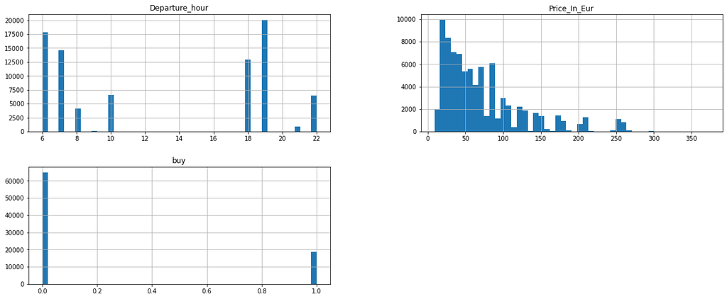

```python
train_set[["Departure_hour", "Price_In_Eur", "buy"]].hist(bins=50, figsize=(20,8))
plt.show()
```

Ein späterer Abflug und erhöhte Preise haben einen kleine negativen Einfluss auf die Kaufempfehlung.

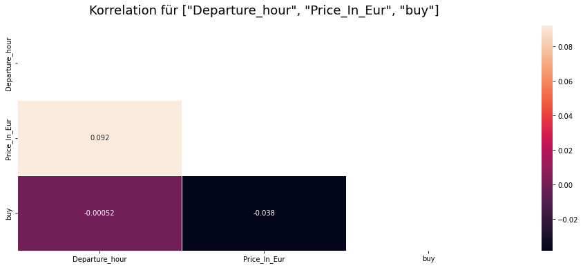

```python
plt.figure(figsize=(16, 6))
# define the mask to set the values in the upper triangle to True
mask = np.triu(np.ones_like(train_set[["Departure_hour", "Price_In_Eur", "buy"]].corr()))
heatmap = sns.heatmap(train_set[["Departure_hour", "Price_In_Eur", "buy"]].corr(), mask=mask, annot=True, linewidths=.5)
heatmap.set_title('Korrelation für ["Departure_hour", "Price_In_Eur", "buy"]', fontdict={'fontsize':18}, pad=16);
```

Dagegen spielt die höhe des Preises bei der Kaufempfehlung keine Rolle. Außerdem kann im Boxplot Rauschen erkannt werden.

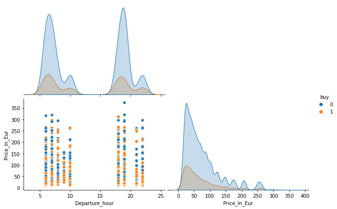

```python
sns.pairplot(train_set[["Departure_hour", "Price_In_Eur", "buy"]], hue="buy", corner=True, height=3, aspect=1.5)
```

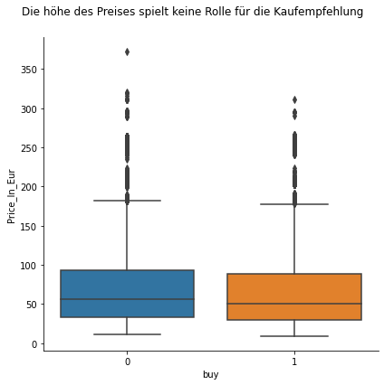

```python
cp = sns.catplot(x="buy", y="Price_In_Eur", kind="box", data=train_set, height=6, aspect=1)
cp.fig.subplots_adjust(top=0.9)
cp.fig.suptitle("Die höhe des Preises spielt keine Rolle für die Kaufempfehlung")
```

### **Beschreibung von qualitative Features.**

```python
or_cat = ["Request_Date", "Flight_Date", "flight_unique_id", "route_abb"]
print("Number of Categories: ")
num_cat(train_set, or_cat)
```

```
Number of Categories:
Request_Date = 123
Flight_Date = 98
flight_unique_id = 1007
route_abb = 4
```

Der Abfragezeitraum war zwischen 03-06-2019 - 03.08.2019.

```python
print(f"Request date range from {train_set.Request_Date.min()} to {train_set.Request_Date.max()}\n")
train_set.Request_Date.value_counts()
```

```
Request date range from 2019-06-03T11:00:00Z to 2019-08-03T11:00:00Z
```

```
2019-06-04T23:00:00Z    996
2019-06-03T23:00:00Z    995
2019-06-05T11:00:00Z    994
2019-06-04T11:00:00Z    985
2019-06-05T23:00:00Z    983
                       ...
2019-08-01T23:00:00Z    414
2019-08-02T11:00:00Z    411
2019-07-31T11:00:00Z    404
2019-08-02T23:00:00Z    402
2019-08-03T11:00:00Z    399
Name: Request_Date, Length: 123, dtype: int64
```

Der Abflugzeitraum für alle angefragten Flüge war zwischen 05.06.2019 - 10.09.2019

```python
print(f"Flight date range from {train_set.Flight_Date.min()} to {train_set.Flight_Date.max()}\n")
train_set.Flight_Date.value_counts()
```

```
Flight date range from 2019-06-05 to 2019-09-10
```

```
2019-08-26    1474
2019-08-15    1472
2019-08-23    1472
2019-08-16    1470
2019-08-09    1470
              ...
2019-06-09      64
2019-06-07      60
2019-06-08      56
2019-06-06      37
2019-06-05      12
Name: Flight_Date, Length: 98, dtype: int64
```

Dabei wurde die Route Schönefeld ✈ Standsted am meisten abgefragt. Der durchschnittlicher Preis war in Endland höher als in Deutschland. Jedoch sind die unterschiede ziemlich gering.

```python
print("Statistik der Routen:")
train_set.route_abb.value_counts()
```

```
Statistik der Routen:
```

```
SXF-STN    27592
STN-SXF    26489
FRA-STN    14950
STN-FRA    14593
Name: route_abb, dtype: int64
```

[output not shown]

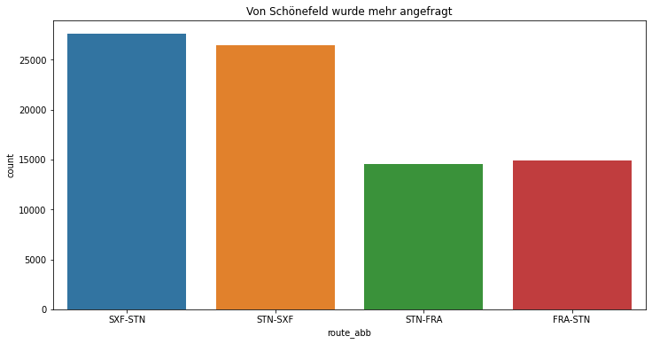

```python
plt.figure(figsize=(12, 6))
sns.countplot(x="route_abb",data=train_set,dodge=False).set(title="Von Schönefeld wurde mehr angefragt")
plt.show()
```

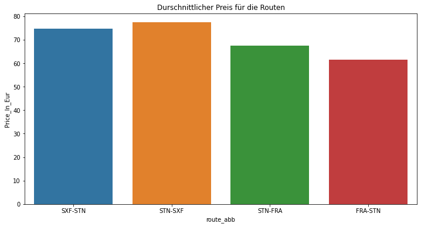

```python
plt.figure(figsize=(12, 6))
sns.barplot(data=train_set, x='route_abb', y='Price_In_Eur', ci=None).set(title="Durschnittlicher Preis für die Routen")
plt.show()
```

Bezogen auf die Entscheidung für Warten oder Kaufen hatte SXF - STN die meisten Kaufempfehlungen. Das kann allerdings ein Ergebnis für die vielen Anfragen sein, sodass die relative Häufigkeit betrachtet werden muss.

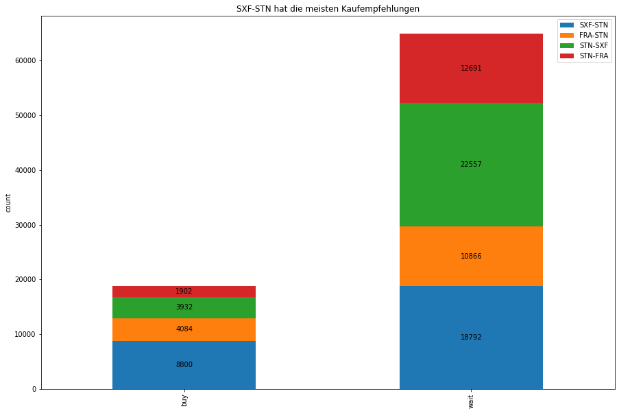

```python
buy = train_set.loc[train_set['buy']==1, :]['route_abb'].value_counts()
wait = train_set.loc[train_set['buy']==0, :]['route_abb'].value_counts()
df  = pd.DataFrame([buy,wait])
df.index=['buy','wait']

# Plot
stacked_plt = df.plot(kind='bar',stacked=True, title='SXF-STN hat die meisten Kaufempfehlungen', figsize=(15,10), ylabel="count")

for bars in stacked_plt.containers:
    labels = [bar.get_height() for bar in bars]
    stacked_plt.bar_label(bars, fmt='%0.0f', label_type='center')
```

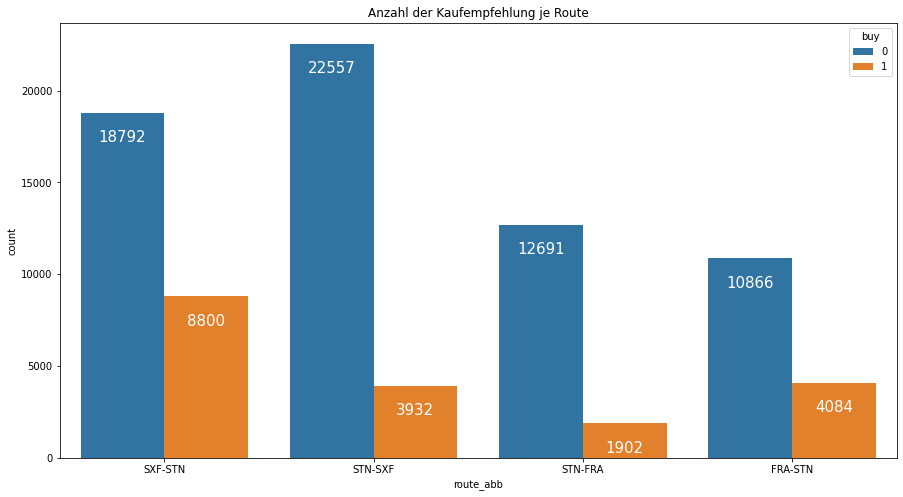

```python
g_count(train_set, "route_abb", "buy", "Anzahl der Kaufempfehlung je Route")
```

Im Histplot ist demnach zu erkennen, dass die Routen SXF-STN auch relativ gesehen zu den meisten Kaufempfehlungen geführt hat. Generell haben Flüge aus Deutschland heraus mehr Kaufempfehlungen gehabt, als die Flüge aus England.

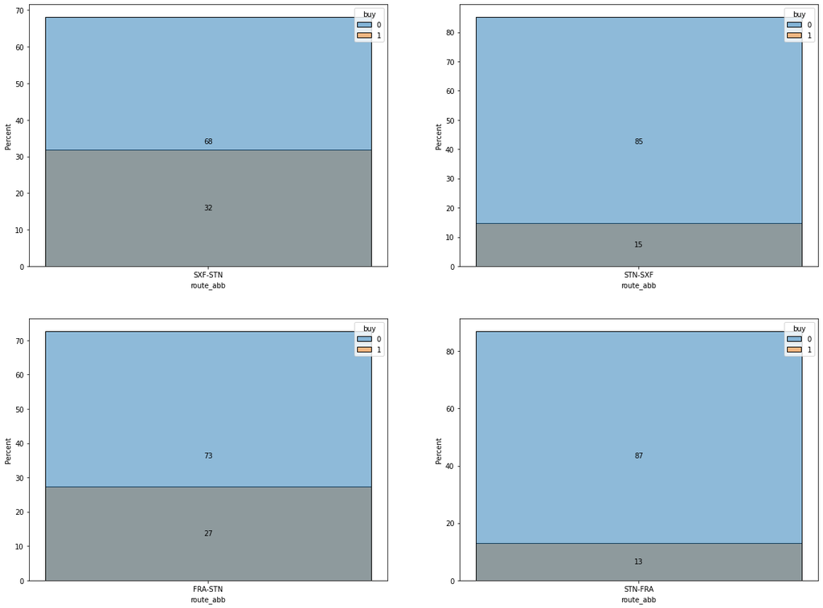

```python
fig, axes = plt.subplots(2, 2, figsize=(20,15))
sns.histplot(x = "route_abb", hue="buy", stat = 'percent', data=train_set[train_set["route_abb"] == "SXF-STN"], ax=axes[0,0])
sns.histplot(x = "route_abb", hue="buy", stat = 'percent', data=train_set[train_set["route_abb"] == "STN-SXF"], ax=axes[0,1])
sns.histplot(x = "route_abb", hue="buy", stat = 'percent', data=train_set[train_set["route_abb"] == "FRA-STN"], ax=axes[1,0])
sns.histplot(x = "route_abb", hue="buy", stat = 'percent', data=train_set[train_set["route_abb"] == "STN-FRA"], ax=axes[1,1])

for ax in axes.reshape(-1):
  for bars in ax.containers:
      ax.bar_label(bars, fmt='%0.0f', label_type='center')

plt.show()
```

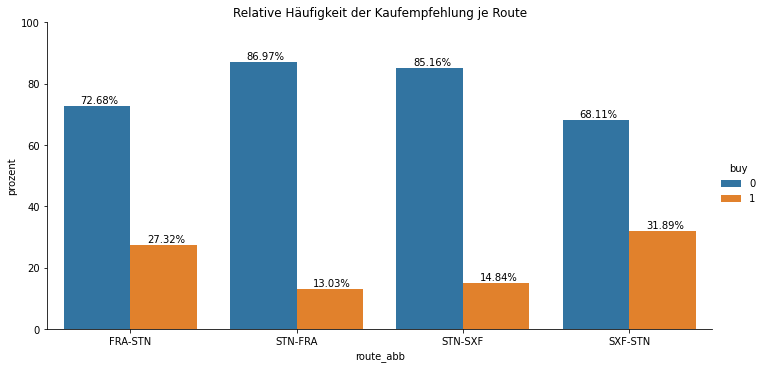

```python
g_percentage(train_set,"route_abb", "buy", "Relative Häufigkeit der Kaufempfehlung je Route")
```

Wird der Preis im Zusammenhang mit der Route betrachtet sticht die Route SXF-STN heraus, da nur an dieser Stelle die Höhe des Preises einen Einfluss auf die Kaufentscheidung hat. Bei alle anderen Routen spielt die Höhe des Preises keine Rolle.

[figure not shown]

```python
cp = sns.catplot(x="route_abb", y="Price_In_Eur", hue="buy",kind="box", data=train_set, height=6, aspect=1)
cp.fig.subplots_adjust(top=0.9)
cp.fig.suptitle("Der Preis in Zusammenhang mit der Route.")
```

Nehmen der Route kann die jeder Flug einzeln betrachtet werden. Dabei wurde ein Flug höchsten 123 Mal und minimal 4 Mal angefragt.

```python
train_set.flight_unique_id.value_counts()
```

```
2019-08-28 FR 146     123
2019-08-15 FR 145     123
2019-08-09 FR 1687    123
2019-08-19 FR 147     123
2019-08-09 FR 8543    123
                     ...
2019-06-10 FR 1547      4
2019-06-05 FR 147       4
2019-06-30 FR 146       4
2019-06-06 FR 1547      4
2019-06-06 FR 144       4
Name: flight_unique_id, Length: 1007, dtype: int64
```

Es lässt sich beobachten, dass für Flüge, die sehr viel angefragt wurden, es generell weniger Kaufempfehlung gab.

```
<function matplotlib.pyplot.show>
```

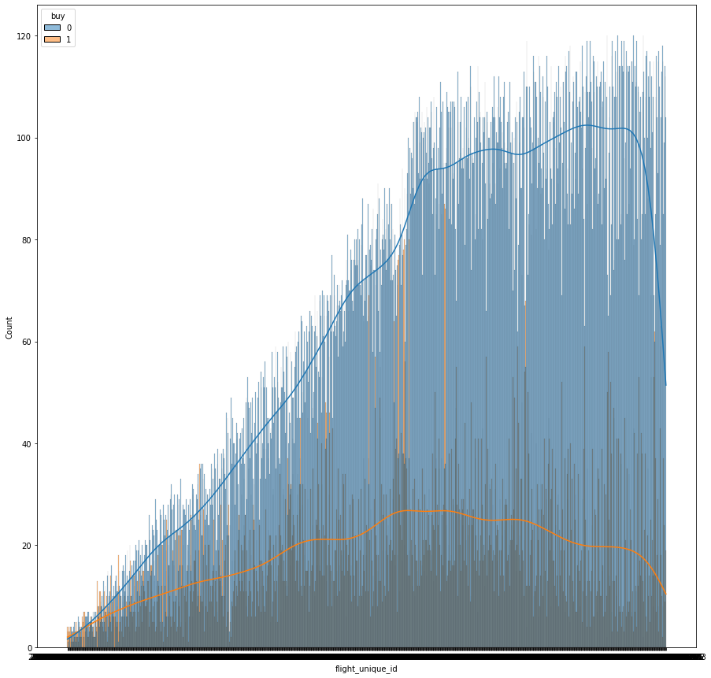

```python
plt.figure(figsize=(15, 15))
ax = sns.histplot(x="flight_unique_id", hue="buy", data=train_set, kde=True)
plt.show
```

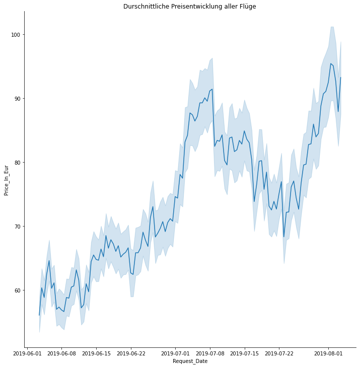

```python
train_set.Request_Date = pd.to_datetime(train_set.Request_Date, format='%Y-%m-%dT%H:%M:%SZ')
sns.relplot(x="Request_Date", y="Price_In_Eur", kind="line", data=train_set, aspect=1, height=10).set(title="Durschnittliche Preisentwicklung aller Flüge")
```

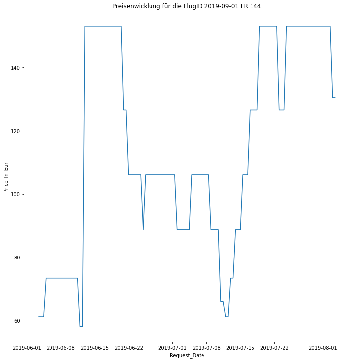

```python
id = "2019-09-01 FR 144"
train_set_copy = train_set.loc[train_set.flight_unique_id==id]
sns.relplot(x="Request_Date", y="Price_In_Eur", kind="line", data=train_set_copy, aspect=1, height=10).set(title=f"Preisenwicklung für die FlugID {id}")
```

### **Datenvorverarbeitung and Feature Engineering**

**Zusätzliche Daten**

- Request_Time (int): Gerundete Anfrageuhrzeit (Stunde)
- Request_Month (int): Monat der Anfrage
- Request_Day (int): Wochentag der Anfrage
- Flight_Month (int): Monat des Fluges
- Flight_Day (int): Wochentag des Fluges
- Hours_to_Flight (int): Anzahl der Stunden von der Anfrage bis zum Flug
- Departure (string): Abflugsort
- Destination (string): Zielort
- Price_Dev (float): Die Preisentwicklung der Anfrage mit Betrachtung auf den vorigen Flug mit der selben Flug ID
- Preis_Dev_Three_Days (float): Preisentwicklung für 3 Tage
- Price_Dev_Cat (String): Die Kategorie der Preisentwicklung (Rising, Falling, Steady)
- Request_Count (int): Die Anzahl an Anfragen bis zur jetzigen Anfrage mit der selben Flug ID
- Request_Count_Sum (int): Die Gesamtzahl der Anfragen für eine Flug ID
- Is_Holiday (int): Ob der Tag des Fluges ein Urlaubstag ist oder nicht (0 oder 1), aufgeteilt nach Land
- Is_School_Holiday (int): Ob an dem Tag des Fluges Schulferien sind (0 oder 1), aufgeteilt nach Berlin, Frankfurt, UK
- flight_unique_id_same_flight_date : ID des Fluges mit dem selben flight_date und route_abb
- Same_Day_Route_Flight_avg_price: Durschnittspreis von den Flug mit dem selben flight_date und route_abb
- Same_Day_Route_Flight_avg_price_utd: Durschnittspreis von den Flug mit dem selben flight_date und route_abb bis zu dem Request_Date
- Same_Day_Request_route_Flight_price: Preis von den Flug mit dem selben flight_date, route_abb und Request_Date
- Last_Request (bool): letztes Request_Date vor Abflug

Mithilfe des folgenden Codes werden die neuen Features dem bestehenden Dataframe angehangen.

```python
# Price_Dev und Price_Dev_Three_Days
train_set['Request_Date'] = pd.to_datetime(train_set['Request_Date']).dt.tz_localize(None)
train_set.sort_values(["flight_unique_id", "Request_Date"])
for i in range(1, len(train_set)):
  flight_unique_id = train_set.loc[i, "flight_unique_id"]
  threeDaysBefore = train_set.loc[i, "Request_Date"] + datetime.timedelta(days = -3)

  if flight_unique_id == train_set.loc[i-1, "flight_unique_id"]:
    train_set.loc[i, "Price_Dev"] = train_set.loc[i, "Price_In_Eur"] - train_set.loc[i-1, "Price_In_Eur"]
  try:
    price = train_set.loc[(train_set["flight_unique_id"] == flight_unique_id) & (train_set["Request_Date"] == threeDaysBefore), "Price_In_Eur"].values
    priceDiff = price[0]
  except:
    priceDiff = 0
  if priceDiff != 0:
    train_set.loc[i, "Price_Dev_Three_Days"] = train_set.loc[i, "Price_In_Eur"] - priceDiff
train_set = train_set.fillna(0)
```

```python
# Request Count
train_set.sort_values(["flight_unique_id", "Request_Date"])
train_set.loc[0, "Request_Count"] = 1
for j in range(1, len(train_set)):
  if train_set.loc[j, "flight_unique_id"] != train_set.loc[j-1, "flight_unique_id"]:
    train_set.loc[j, "Request_Count"] = 1
  else:
    train_set.loc[j, "Request_Count"] = train_set.loc[j-1, "Request_Count"] + 1
```

```python
# Last Request
train_set["Last_Request"] = [train_set[train_set.flight_unique_id==flightid]["Request_Date"].max() for flightid in train_set["flight_unique_id"]]
```

```python
train_set.loc[(train_set["Last_Request"] == train_set["Request_Date"]), "Last_Request_Bool"] = 1
train_set = train_set.fillna(0)
```

```python
# Sum of Request
train_set["Request_Count_Sum"] = [len(train_set[train_set.flight_unique_id == flightID]) for flightID in train_set["flight_unique_id"]]
```

```python
train_set.loc[train_set['Price_Dev'] > 0, 'Price_Dev_Cat'] = "Rising"
train_set.loc[train_set['Price_Dev'] < 0, 'Price_Dev_Cat'] = "Falling"
train_set.loc[train_set['Price_Dev'] == 0, 'Price_Dev_Cat'] = "Steady"
train_set['Flight_Date'] = pd.to_datetime(train_set['Flight_Date'], format="%Y-%m-%d").dt.tz_localize(None)
train_set["Flight_Date_Time"] = train_set["Flight_Date"] + pd.to_timedelta(train_set.Departure_hour, unit="h")
train_set['Request_Month'] = pd.DatetimeIndex(train_set['Request_Date']).month
train_set['Flight_Month'] = pd.DatetimeIndex(train_set['Flight_Date']).month
train_set['Request_Time'] = pd.DatetimeIndex(train_set['Request_Date']).hour
train_set['Request_Day'] = pd.DatetimeIndex(train_set['Request_Date']).day_name()
train_set['Flight_Day'] = pd.DatetimeIndex(train_set['Flight_Date']).day_name()
train_set['Hours_to_Flight'] = ((train_set['Flight_Date_Time'] - train_set['Request_Date']).dt.total_seconds() / 3600).astype(int)
train_set['Departure'] = train_set["route_abb"].apply(split_departure)
train_set['Destination'] = train_set["route_abb"].apply(split_destination)
```

```python
# Warning: this will take a lot of time

# return avg price and id of same flight
Same_Day_route_Flight_avg_price = [train_set[(train_set.flight_unique_id!=flightid) & (train_set.Flight_Date_Time==flightdate) & (train_set.route_abb==route)].groupby(["flight_unique_id"])["Price_In_Eur"].mean().reset_index() for flightid, flightdate, route in zip(train_set["flight_unique_id"], train_set["Flight_Date_Time"], train_set["route_abb"])]

# return price of same flight with same request date
Same_Day_Request_route_Flight_price = [train_set[(train_set.flight_unique_id!=flightid) & (train_set.Flight_Date_Time==flightdate) & (train_set.route_abb==route) & (train_set.Request_Date==requestdate)][["Price_In_Eur"]] for flightid, flightdate, route, requestdate in zip(train_set["flight_unique_id"], train_set["Flight_Date_Time"], train_set["route_abb"], train_set["Request_Date"])]

# return avg price and id of same flight up to i Request Date
Same_Day_route_Flight_avg_price_utd = [train_set[(train_set.flight_unique_id!=flightid) & (train_set.Flight_Date_Time==flightdate) & (train_set.route_abb==route) & (train_set.Request_Date<=requestdate)].groupby(["flight_unique_id"])["Price_In_Eur"].mean().reset_index() for flightid, flightdate, route, requestdate in zip(train_set["flight_unique_id"], train_set["Flight_Date_Time"], train_set["route_abb"], train_set["Request_Date"])]

# make features into dataframes and concat all together
df = concat_empty_dfs(Same_Day_route_Flight_avg_price, ["flight_unique_id", "Price_In_Eur"])
df = df.rename(columns={"Price_In_Eur":"Same_Day_Route_Flight_avg_price"})
df2 = concat_empty_dfs(Same_Day_route_Flight_avg_price_utd, ["flight_unique_id", "Price_In_Eur"])
df2 = df2.rename(columns={"Price_In_Eur":"Same_Day_Route_Flight_avg_price_utd"})
df3 = concat_empty_dfs(Same_Day_Request_route_Flight_price, ["Index", "Price_In_Eur"])
df3 = df3.rename(columns={"Price_In_Eur":"Same_Day_Request_route_Flight_price"})
df_same_day_flight_feature = pd.concat([df, df2["Same_Day_Route_Flight_avg_price_utd"], df3["Same_Day_Request_route_Flight_price"]], axis=1)
df_same_day_flight_feature = df_same_day_flight_feature.rename(columns={"flight_unique_id":"flight_unique_id_same_flight_date"})

#join with train_set
train_set = pd.concat([train_set, df_same_day_flight_feature], axis=1)
```

```python
train_set.head()
```

|  | Request_Date | Flight_Date | Departure_hour | flight_unique_id | route_abb | Price_In_Eur | min_future_price_in_Eur | buy | Price_Dev | Price_Dev_Three_Days | ... | Request_Time | Request_Day | Flight_Day | Hours_to_Flight | Departure | Destination | flight_unique_id_same_flight_date | Same_Day_Route_Flight_avg_price | Same_Day_Route_Flight_avg_price_utd | Same_Day_Request_route_Flight_price |
| --- | --- | --- | --- | --- | --- | --- | --- | --- | --- | --- | --- | --- | --- | --- | --- | --- | --- | --- | --- | --- | --- |
| 0 | 2019-06-03 11:00:00 | 2019-06-05 | 19 | 2019-06-05 FR 146 | SXF-STN | 208.07 | 259.07 | 1 | 0.0 | 0.0 | ... | 11 | Monday | Wednesday | 56 | SXF | STN | 0 | 0.0 | 0.0 | 0.0 |
| 1 | 2019-06-03 23:00:00 | 2019-06-05 | 19 | 2019-06-05 FR 146 | SXF-STN | 259.07 | 259.07 | 1 | 51.0 | 0.0 | ... | 23 | Monday | Wednesday | 44 | SXF | STN | 0 | 0.0 | 0.0 | 0.0 |
| 2 | 2019-06-04 11:00:00 | 2019-06-05 | 19 | 2019-06-05 FR 146 | SXF-STN | 259.07 | 259.07 | 1 | 0.0 | 0.0 | ... | 11 | Tuesday | Wednesday | 32 | SXF | STN | 0 | 0.0 | 0.0 | 0.0 |
| 3 | 2019-06-04 23:00:00 | 2019-06-05 | 19 | 2019-06-05 FR 146 | SXF-STN | 259.07 | 259.07 | 1 | 0.0 | 0.0 | ... | 23 | Tuesday | Wednesday | 20 | SXF | STN | 0 | 0.0 | 0.0 | 0.0 |
| 4 | 2019-06-03 11:00:00 | 2019-06-05 | 21 | 2019-06-05 FR 147 | STN-SXF | 143.86 | 251.72 | 1 | 0.0 | 0.0 | ... | 11 | Monday | Wednesday | 58 | STN | SXF | 0 | 0.0 | 0.0 | 0.0 |

5 rows × 28 columns

Um zu erkennen, ob am Abflugdatum ein Feiertag ist, wurde die holidays Library genutzt. Um des Weiteren zu erkennen, ob am Abflugdatum Schulferien sind, wurden die einzelnen Daten der Schulferien je nach Land und Bundesland herausgesucht. Anschließend wurden diese einem Dataframe zugeordnet und mit den Trainingsdaten abgeglichen, um die Features Is_Holiday und Is_School_Holiday zu erstellen.

```python
uk_holidays = []
ger_holidays = []
for date in holidays.UnitedKingdom(years=2019).items():
  uk_holidays.append(str(date[0]))
for date in holidays.Germany(years=2019).items():
  ger_holidays.append(str(date[0]))
train_set['Is_Holiday_UK'] = [1 if str(val).split()[0] in uk_holidays else 0 for val in train_set['Flight_Date']]
train_set['Is_Holiday_GER'] = [1 if str(val).split()[0] in ger_holidays else 0 for val in train_set['Flight_Date']]

berlin_vacation1_start = datetime.datetime(year=2019, month=5, day = 31)
berlin_vacation1_end = datetime.datetime(year=2019, month=6, day = 11)
berlin_vacation2_start = datetime.datetime(year=2019, month=6, day=20)
berlin_vacation2_end = datetime.datetime(year=2019, month=8, day = 2)
frankfurt_vacation_start = datetime.datetime(year=2019, month = 7, day = 1)
frankfurt_vacation_end = datetime.datetime(year=2019, month=8, day=9)
uk_vacation_start = datetime.datetime(year=2019, month=7, day=6)
uk_vacation_end = datetime.datetime(year=2019, month=9, day=3)

berlin_school_holidays1 = pd.DataFrame()
berlin_school_holidays2 = pd.DataFrame()
berlin_school_holidays = pd.DataFrame()
frankfurt_school_holidays = pd.DataFrame()
uk_school_holidays = pd.DataFrame()

berlin_school_holidays1["Date"] = pd.date_range(berlin_vacation1_start, berlin_vacation1_end)
berlin_school_holidays2["Date"] = pd.date_range(berlin_vacation2_start, berlin_vacation2_end)
berlin_school_holidays = berlin_school_holidays1.append(berlin_school_holidays2, ignore_index = True)
frankfurt_school_holidays["Date"] = pd.date_range(frankfurt_vacation_start, frankfurt_vacation_end)
uk_school_holidays["Date"] = pd.date_range(uk_vacation_start, uk_vacation_end)

train_set['Is_School_Holiday_BER'] = train_set["Flight_Date"].isin(berlin_school_holidays["Date"]).astype(int)
train_set['Is_School_Holiday_FRA'] = train_set["Flight_Date"].isin(frankfurt_school_holidays["Date"]).astype(int)
train_set['Is_School_Holiday_UK'] = train_set["Flight_Date"].isin(uk_school_holidays["Date"]).astype(int)
```

```python
train_set.head()
```

|  | Request_Date | Flight_Date | Departure_hour | flight_unique_id | route_abb | Price_In_Eur | min_future_price_in_Eur | buy | Price_Dev | Price_Dev_Three_Days | ... | Destination | flight_unique_id_same_flight_date | Same_Day_Route_Flight_avg_price | Same_Day_Route_Flight_avg_price_utd | Same_Day_Request_route_Flight_price | Is_Holiday_UK | Is_Holiday_GER | Is_School_Holiday_BER | Is_School_Holiday_FRA | Is_School_Holiday_UK |
| --- | --- | --- | --- | --- | --- | --- | --- | --- | --- | --- | --- | --- | --- | --- | --- | --- | --- | --- | --- | --- | --- |
| 0 | 2019-06-03 11:00:00 | 2019-06-05 | 19 | 2019-06-05 FR 146 | SXF-STN | 208.07 | 259.07 | 1 | 0.0 | 0.0 | ... | STN | 0 | 0.0 | 0.0 | 0.0 | 0 | 0 | 1 | 0 | 0 |
| 1 | 2019-06-03 23:00:00 | 2019-06-05 | 19 | 2019-06-05 FR 146 | SXF-STN | 259.07 | 259.07 | 1 | 51.0 | 0.0 | ... | STN | 0 | 0.0 | 0.0 | 0.0 | 0 | 0 | 1 | 0 | 0 |
| 2 | 2019-06-04 11:00:00 | 2019-06-05 | 19 | 2019-06-05 FR 146 | SXF-STN | 259.07 | 259.07 | 1 | 0.0 | 0.0 | ... | STN | 0 | 0.0 | 0.0 | 0.0 | 0 | 0 | 1 | 0 | 0 |
| 3 | 2019-06-04 23:00:00 | 2019-06-05 | 19 | 2019-06-05 FR 146 | SXF-STN | 259.07 | 259.07 | 1 | 0.0 | 0.0 | ... | STN | 0 | 0.0 | 0.0 | 0.0 | 0 | 0 | 1 | 0 | 0 |
| 4 | 2019-06-03 11:00:00 | 2019-06-05 | 21 | 2019-06-05 FR 147 | STN-SXF | 143.86 | 251.72 | 1 | 0.0 | 0.0 | ... | SXF | 0 | 0.0 | 0.0 | 0.0 | 0 | 0 | 1 | 0 | 0 |

5 rows × 33 columns

```python
train_set.info()
```

```
<class 'pandas.core.frame.DataFrame'>
RangeIndex: 83624 entries, 0 to 83623
Data columns (total 33 columns):
 #   Column                               Non-Null Count  Dtype
---  ------                               --------------  -----
 0   Request_Date                         83624 non-null  datetime64[ns]
 1   Flight_Date                          83624 non-null  datetime64[ns]
 2   Departure_hour                       83624 non-null  int64
 3   flight_unique_id                     83624 non-null  object
 4   route_abb                            83624 non-null  object
 5   Price_In_Eur                         83624 non-null  float64
 6   min_future_price_in_Eur              83624 non-null  float64
 7   buy                                  83624 non-null  int64
 8   Price_Dev                            83624 non-null  float64
 9   Price_Dev_Three_Days                 83624 non-null  float64
```

[output cut: 25 more lines]

Nach hinzufügen der Features wurde das Dataframe auf die wesentlichen Features reduziert. Das Dataframe hat nun folgende Spalten:

```python
train_set_v2 = train_set[["buy", "Price_In_Eur", "Price_Dev", "Price_Dev_Three_Days", "Request_Day", "Request_Month",
                       "Request_Time", "Last_Request_Bool", "Flight_Day", "Departure_hour",
                       "Hours_to_Flight", "Departure", "Destination", "Price_Dev_Cat", "Request_Count", "Request_Count_Sum", "Is_Holiday_UK", "Is_Holiday_GER", "Is_School_Holiday_BER", "Is_School_Holiday_FRA", "Is_School_Holiday_UK",
                       "flight_unique_id_same_flight_date", "Same_Day_Route_Flight_avg_price", "Same_Day_Route_Flight_avg_price_utd", "Same_Day_Request_route_Flight_price"]]
train_set_v2.head()
```

|  | buy | Price_In_Eur | Price_Dev | Price_Dev_Three_Days | Request_Day | Request_Month | Request_Time | Last_Request_Bool | Flight_Day | Departure_hour | ... | Request_Count_Sum | Is_Holiday_UK | Is_Holiday_GER | Is_School_Holiday_BER | Is_School_Holiday_FRA | Is_School_Holiday_UK | flight_unique_id_same_flight_date | Same_Day_Route_Flight_avg_price | Same_Day_Route_Flight_avg_price_utd | Same_Day_Request_route_Flight_price |
| --- | --- | --- | --- | --- | --- | --- | --- | --- | --- | --- | --- | --- | --- | --- | --- | --- | --- | --- | --- | --- | --- |
| 0 | 1 | 208.07 | 0.0 | 0.0 | Monday | 6 | 11 | 0.0 | Wednesday | 19 | ... | 4 | 0 | 0 | 1 | 0 | 0 | 0 | 0.0 | 0.0 | 0.0 |
| 1 | 1 | 259.07 | 51.0 | 0.0 | Monday | 6 | 23 | 0.0 | Wednesday | 19 | ... | 4 | 0 | 0 | 1 | 0 | 0 | 0 | 0.0 | 0.0 | 0.0 |
| 2 | 1 | 259.07 | 0.0 | 0.0 | Tuesday | 6 | 11 | 0.0 | Wednesday | 19 | ... | 4 | 0 | 0 | 1 | 0 | 0 | 0 | 0.0 | 0.0 | 0.0 |
| 3 | 1 | 259.07 | 0.0 | 0.0 | Tuesday | 6 | 23 | 1.0 | Wednesday | 19 | ... | 4 | 0 | 0 | 1 | 0 | 0 | 0 | 0.0 | 0.0 | 0.0 |
| 4 | 1 | 143.86 | 0.0 | 0.0 | Monday | 6 | 11 | 0.0 | Wednesday | 21 | ... | 4 | 0 | 0 | 1 | 0 | 0 | 0 | 0.0 | 0.0 | 0.0 |

5 rows × 25 columns

```python
train_set_v2.info()
```

```
<class 'pandas.core.frame.DataFrame'>
RangeIndex: 83624 entries, 0 to 83623
Data columns (total 25 columns):
 #   Column                               Non-Null Count  Dtype
---  ------                               --------------  -----
 0   buy                                  83624 non-null  int64
 1   Price_In_Eur                         83624 non-null  float64
 2   Price_Dev                            83624 non-null  float64
 3   Price_Dev_Three_Days                 83624 non-null  float64
 4   Request_Day                          83624 non-null  object
 5   Request_Month                        83624 non-null  int64
 6   Request_Time                         83624 non-null  int64
 7   Last_Request_Bool                    83624 non-null  float64
 8   Flight_Day                           83624 non-null  object
 9   Departure_hour                       83624 non-null  int64
```

[output cut: 17 more lines]

Die verarbeiteten Daten werden in eine CSV gespeichert. Dadurch muss der Code nicht nochmal durchgeführt werden.

```python
train_set_v2.to_csv("/content/drive/MyDrive/Data Mining Gruppe A/train_set_v2.csv", index=False)
```

```python
train_set_v2 = load_data_set("/content/drive/MyDrive/Data Mining Gruppe A/train_set_v2.csv") # shortcut shared drive
# train_set_v2 = load_data_set("train_set_v2.csv")
train_set_v2
```

|  | buy | Price_In_Eur | Price_Dev | Price_Dev_Three_Days | Request_Day | Request_Month | Request_Time | Last_Request_Bool | Flight_Day | Departure_hour | ... | Request_Count_Sum | Is_Holiday_UK | Is_Holiday_GER | Is_School_Holiday_BER | Is_School_Holiday_FRA | Is_School_Holiday_UK | flight_unique_id_same_flight_date | Same_Day_Route_Flight_avg_price | Same_Day_Route_Flight_avg_price_utd | Same_Day_Request_route_Flight_price |
| --- | --- | --- | --- | --- | --- | --- | --- | --- | --- | --- | --- | --- | --- | --- | --- | --- | --- | --- | --- | --- | --- |
| 0 | 1 | 208.07 | 0.00 | 0.00 | Monday | 6 | 11 | 0.0 | Wednesday | 19 | ... | 4 | 0 | 0 | 1 | 0 | 0 | 0 | 0.0 | 0.0 | 0.0 |
| 1 | 1 | 259.07 | 51.00 | 0.00 | Monday | 6 | 23 | 0.0 | Wednesday | 19 | ... | 4 | 0 | 0 | 1 | 0 | 0 | 0 | 0.0 | 0.0 | 0.0 |
| 2 | 1 | 259.07 | 0.00 | 0.00 | Tuesday | 6 | 11 | 0.0 | Wednesday | 19 | ... | 4 | 0 | 0 | 1 | 0 | 0 | 0 | 0.0 | 0.0 | 0.0 |
| 3 | 1 | 259.07 | 0.00 | 0.00 | Tuesday | 6 | 23 | 1.0 | Wednesday | 19 | ... | 4 | 0 | 0 | 1 | 0 | 0 | 0 | 0.0 | 0.0 | 0.0 |
| 4 | 1 | 143.86 | 0.00 | 0.00 | Monday | 6 | 11 | 0.0 | Wednesday | 21 | ... | 4 | 0 | 0 | 1 | 0 | 0 | 0 | 0.0 | 0.0 | 0.0 |
| ... | ... | ... | ... | ... | ... | ... | ... | ... | ... | ... | ... | ... | ... | ... | ... | ... | ... | ... | ... | ... | ... |
| 83619 | 1 | 35.69 | 0.00 | 6.12 | Thursday | 8 | 11 | 0.0 | Tuesday | 10 | ... | 123 | 0 | 0 | 0 | 0 | 0 | 0 | 0.0 | 0.0 | 0.0 |
| 83620 | 0 | 46.83 | 11.14 | 17.26 | Thursday | 8 | 23 | 0.0 | Tuesday | 10 | ... | 123 | 0 | 0 | 0 | 0 | 0 | 0 | 0.0 | 0.0 | 0.0 |
| 83621 | 0 | 46.83 | 0.00 | 17.26 | Friday | 8 | 11 | 0.0 | Tuesday | 10 | ... | 123 | 0 | 0 | 0 | 0 | 0 | 0 | 0.0 | 0.0 | 0.0 |
| 83622 | 1 | 39.69 | -7.14 | 4.00 | Friday | 8 | 23 | 0.0 | Tuesday | 10 | ... | 123 | 0 | 0 | 0 | 0 | 0 | 0 | 0.0 | 0.0 | 0.0 |
| 83623 | 1 | 39.69 | 0.00 | 4.00 | Saturday | 8 | 11 | 1.0 | Tuesday | 10 | ... | 123 | 0 | 0 | 0 | 0 | 0 | 0 | 0.0 | 0.0 | 0.0 |

83624 rows × 25 columns

Wie an folgender Grafik zu erkennen ist, hat der Wochentag einen Einfluss auf den Preis.

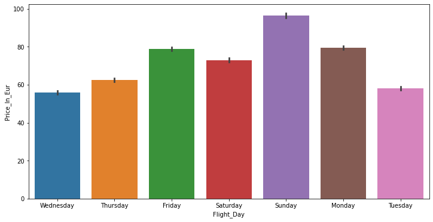

```python
plt.figure(figsize=(12, 6))
sns.barplot(data=train_set_v2, x='Flight_Day', y='Price_In_Eur')
plt.show()
```

Jedoch hat der Wochentag, wie an folgender Grafik zu erkennen ist, keinen, oder wenn nur einen geringen Einfluss auf die Kaufempfehlung. Von Mittwoch bis Donnerstag haben wir eine erhöhte Kaufempfehlung.

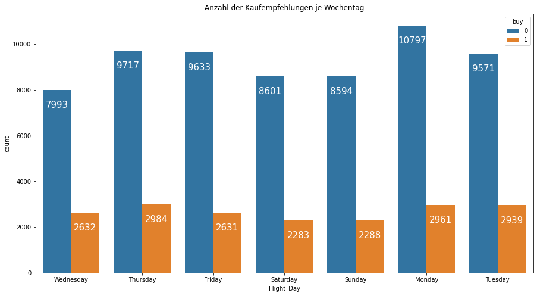

```python
g_count(train_set_v2, "Flight_Day", "buy", "Anzahl der Kaufempfehlungen je Wochentag")
```

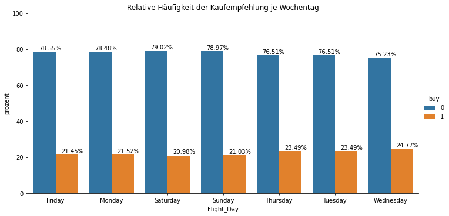

```python
g_percentage(train_set_v2, "Flight_Day", "buy", "Relative Häufigkeit der Kaufempfehlung je Wochentag")
```

Hier ist zu erkennen, dass die Abflugzeit einen Einfluss auf die Kaufempfehlung hat. Der Anteil an Kaufempfehlungen ist um 6, 10, 18 und 22 Uhr höher als bei anderen Uhrzeiten.

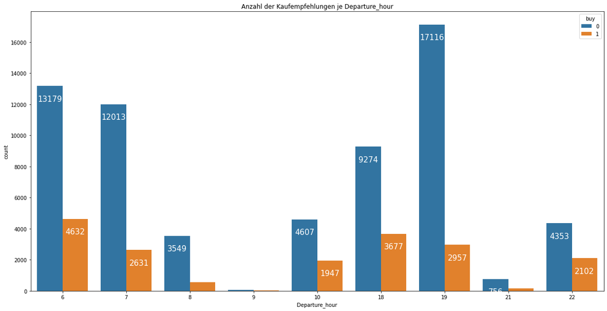

```python
g_count(train_set_v2, "Departure_hour", "buy", "Anzahl der Kaufempfehlungen je Departure_hour", 20,10)
```

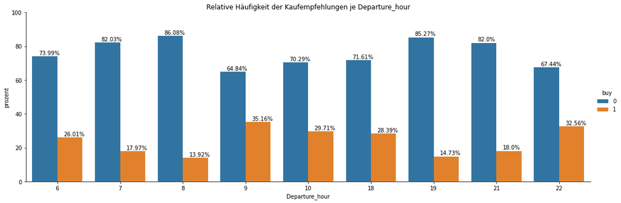

```python
g_percentage(train_set_v2, "Departure_hour", "buy", "Relative Häufigkeit der Kaufempfehlungen je Departure_hour", width=3)
```

Anhand folgender Grafik ist zu erkennen, dass die Request_Time gar keinen Einfluss auf die Kaufentscheidung hat.

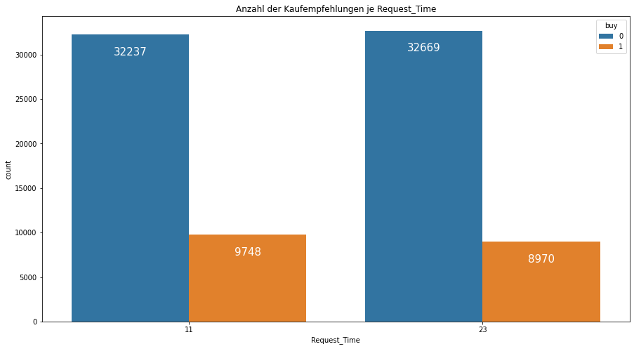

```python
g_count(train_set_v2, "Request_Time", "buy", "Anzahl der Kaufempfehlungen je Request_Time")
```

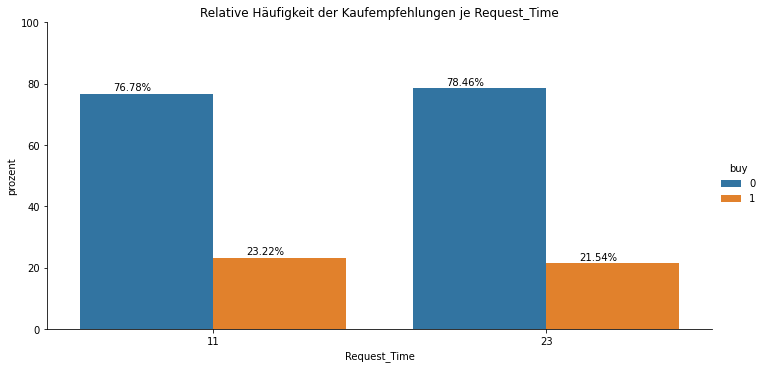

```python
g_percentage(train_set_v2, "Request_Time", "buy", "Relative Häufigkeit der Kaufempfehlungen je Request_Time")
```

Wie hier zu erkennen ist, gibt es einen besonders großen Anteil an Kaufempfehlungen bei deutschen Feiertagen. Dies könnte aber auf die geringe Datenmenge zurückzuführen sein, da hier nur der Pfingstmontag betrachtet wird.

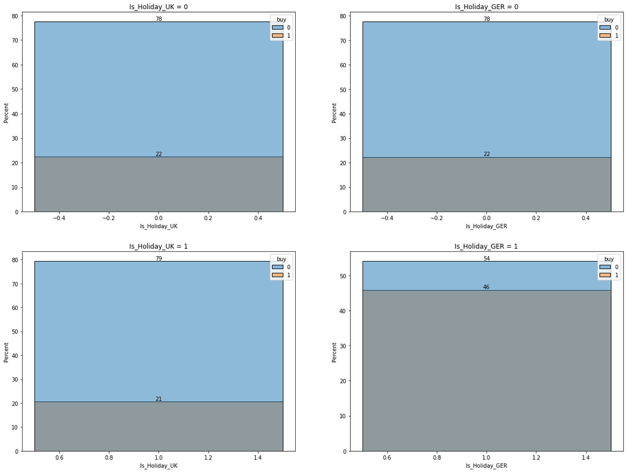

```python
fig, axes = plt.subplots(2,2, figsize=(20,15))
sns.histplot(x = "Is_Holiday_UK", hue="buy", stat = 'percent', data=train_set[train_set["Is_Holiday_UK"] == 0], ax=axes[0,0]).set_title("Is_Holiday_UK = 0")
sns.histplot(x = "Is_Holiday_GER", hue="buy", stat = 'percent', data=train_set[train_set["Is_Holiday_GER"] == 0], ax=axes[0,1]).set_title("Is_Holiday_GER = 0")
sns.histplot(x = "Is_Holiday_UK", hue="buy", stat = 'percent', data=train_set[train_set["Is_Holiday_UK"] == 1], ax=axes[1,0]).set_title("Is_Holiday_UK = 1")
sns.histplot(x = "Is_Holiday_GER", hue="buy", stat = 'percent', data=train_set[train_set["Is_Holiday_GER"] == 1], ax=axes[1,1]).set_title("Is_Holiday_GER = 1")

for ax in axes.reshape(-1):
  for bars in ax.containers:
      ax.bar_label(bars, fmt='%0.0f')

plt.show()
```

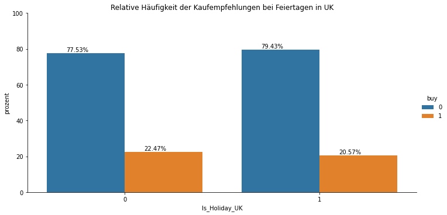

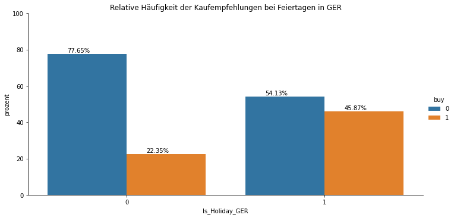

```python
g_percentage(train_set_v2, "Is_Holiday_UK", "buy", "Relative Häufigkeit der Kaufempfehlungen bei Feiertagen in UK")
g_percentage(train_set_v2, "Is_Holiday_GER", "buy", "Relative Häufigkeit der Kaufempfehlungen bei Feiertagen in GER")
```

Die Schulferien haben laut folgender Grafik nur einen geringen Einfluss auf die Anzahl der Kaufempfehlungen.

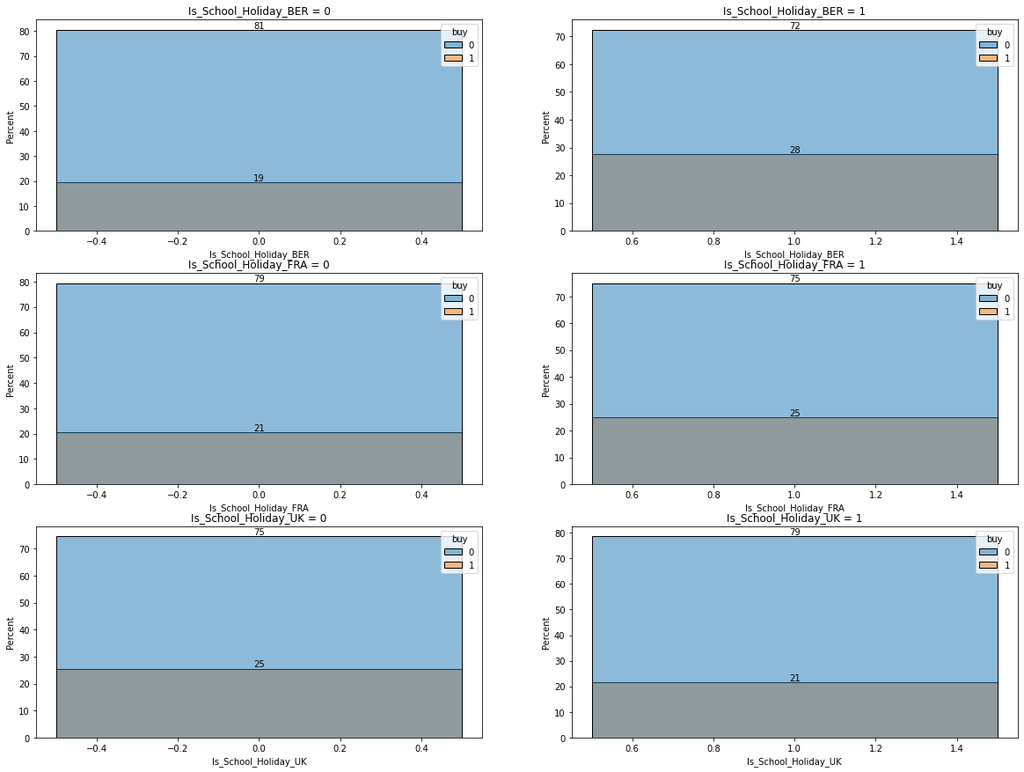

```python
fig, axes = plt.subplots(nrows=3,ncols=2, figsize=(20,15))
sns.histplot(x = 'Is_School_Holiday_BER', hue="buy", stat = 'percent', data=train_set[train_set['Is_School_Holiday_BER'] == 0], ax=axes[0,0]).set_title("Is_School_Holiday_BER = 0")
sns.histplot(x = 'Is_School_Holiday_BER', hue="buy", stat = 'percent', data=train_set[train_set['Is_School_Holiday_BER'] == 1], ax=axes[0,1]).set_title("Is_School_Holiday_BER = 1")
sns.histplot(x = 'Is_School_Holiday_FRA', hue="buy", stat = 'percent', data=train_set[train_set['Is_School_Holiday_FRA'] == 0], ax=axes[1,0]).set_title("Is_School_Holiday_FRA = 0")
sns.histplot(x = 'Is_School_Holiday_FRA', hue="buy", stat = 'percent', data=train_set[train_set['Is_School_Holiday_FRA'] == 1], ax=axes[1,1]).set_title("Is_School_Holiday_FRA = 1")
sns.histplot(x = 'Is_School_Holiday_UK', hue="buy", stat = 'percent', data=train_set[train_set['Is_School_Holiday_UK'] == 0], ax=axes[2,0]).set_title("Is_School_Holiday_UK = 0")
sns.histplot(x = 'Is_School_Holiday_UK', hue="buy", stat = 'percent', data=train_set[train_set['Is_School_Holiday_UK'] == 1], ax=axes[2,1]).set_title("Is_School_Holiday_UK = 1")

for ax in axes.reshape(-1):
  for bars in ax.containers:
      ax.bar_label(bars, fmt='%0.0f')

plt.show()
```

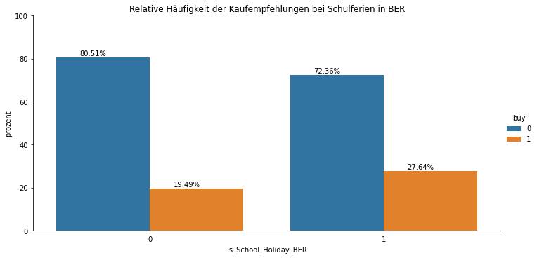

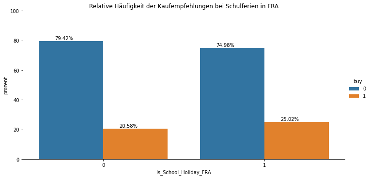

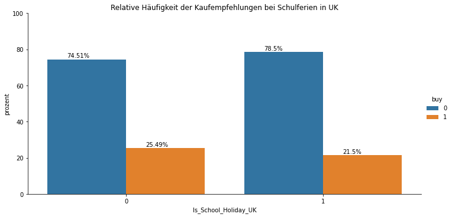

```python
g_percentage(train_set_v2, "Is_School_Holiday_BER", "buy", "Relative Häufigkeit der Kaufempfehlungen bei Schulferien in BER")
g_percentage(train_set_v2, "Is_School_Holiday_FRA", "buy", "Relative Häufigkeit der Kaufempfehlungen bei Schulferien in FRA")
g_percentage(train_set_v2, "Is_School_Holiday_UK", "buy", "Relative Häufigkeit der Kaufempfehlungen bei Schulferien in UK")
```

Wie hier zu sehen ist, steigt die Anzahl an Kaufempfehlungen je geringer die Stunden bis zum Abflug sind.

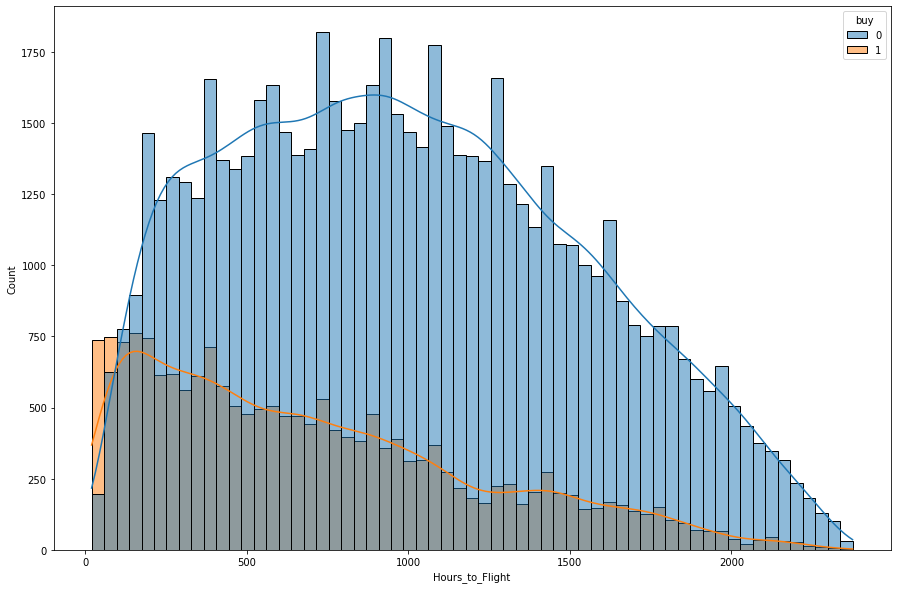

```python
plt.figure(figsize=(15,10))
sns.histplot(x="Hours_to_Flight", hue="buy", data=train_set_v2, kde=True)
plt.show()
```

Anhand folgender Grafik kann gesehen werden, dass der Anteil an Kaufempfehlungen fast immer gleich bleibt und somit der Request_Count keinen großen Einfluss auf die Kaufempfehlung nimmt.

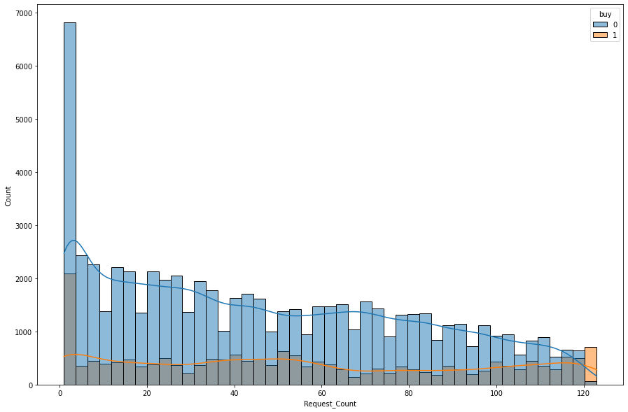

```python
plt.figure(figsize=(15,10))
sns.histplot(x="Request_Count", hue="buy", data=train_set_v2, kde=True)
plt.show()
```